# SF1_microbe_beta_div

Stephen Formel

1/2/2021

## Description and notes

Run PERMANOVA and make PCA, PCoA, and NMDS of 16S and ITS based on Aitchison, Bray Curtis and Jaccard

## Set up aesthetic for plotting

```r
SF1_aes <- aes(x = Treatment,
               y = value,
               shape = soil,
               fill = oil)

my.scale_aes <- list(geom_point(size = 4),
                     geom_polygon(alpha = 0.5),
                     scale_shape_manual(values = c(21,24)),
                     scale_fill_manual(values = c("lightgray", "black")),
                     theme_bw(),
                     guides(fill = guide_legend(override.aes=list(shape=21, size = 4)),
                            shape = guide_legend(override.aes=list(size = 4))),
                     labs(shape = "Soil",
                          fill = "Oil"),
                     theme(plot.title = element_text(hjust = 0.5)))
```

## Import 16S phyloseq object and clean

```r
#read in data
seqtab.nochim <- readRDS("../../data/metagenome/16S/dada2/16S_soil_otu.rds")
samdf <- readRDS("../../data/metagenome/16s/dada2/16S_soil_env.rds")
taxa <- readRDS("../../data/metagenome/16s/dada2/16S_soil_taxa.rds")

SF1 <- phyloseq(otu_table(seqtab.nochim, taxa_are_rows=FALSE),
               sample_data(samdf),
               tax_table(taxa))

#add sampleID to match ITS
sample_data(SF1)$sampleID <- paste0("SF1_", rownames(sample_data(SF1)))
sample_data(SF1)$sampleID <- str_replace_all(sample_data(SF1)$sampleID,
                                             "LN",
                                             "SLN")
sample_data(SF1)$sampleID <- str_replace_all(sample_data(SF1)$sampleID,
                                             "LY",
                                             "SLY")
sample_data(SF1)$sampleID <- str_replace_all(sample_data(SF1)$sampleID,
                                             "SN",
                                             "SSN")
sample_data(SF1)$sampleID <- str_replace_all(sample_data(SF1)$sampleID,
                                             "SY",
                                             "SSY")

#Replace sample data


samdf <- as.data.frame(read_excel("../../data/soil_chem/SF1_soil_chem_all_data.xls",
                                  sheet = "data_cleaned"))

#reorder to match
samdf <- samdf[match(sample_data(SF1)$sampleID, samdf$sampleID),]

#do any sampleID not match?
any(sample_data(SF1)$sampleID!=samdf$sampleID)
```

```
## [1] FALSE
```

```r
#replace rownames on both
rownames(samdf) <- samdf$sampleID
sample_names(SF1) <- sample_data(SF1)$sampleID

#double check that rownames matches sampleID
any(rownames(samdf)!=samdf$sampleID)
```

```
## [1] FALSE
```

```r
#cleaning and fixing

#reorder factors
samdf$time <- factor(samdf$time, levels = c("pre-exp","post-exp"))

#rename factors
library(plyr)
samdf$soil <- revalue(samdf$soil, c("L"="Live Soil", "S"="Autoclaved Soil"))
samdf$oil <- revalue(samdf$oil, c("Y"="Oiled", "N"="No Oil"))
samdf$time <- revalue(samdf$time, c("pre-exp"="Pre-Experiment", "post-exp"="Post-Experiment"))

#rename chem titles
colnames(samdf) <- c("sampleID", "soil", "oil", "time", "Calcium", "Copper", "Magnesium", "pH", "Phosphorus", "Potassium",  "Sodium", "Sulfur", "Zinc", "Percent Carbon", "Percent Nitrogen")

samdf$Treatment <- interaction(samdf$soil, samdf$oil, sep = " , ")
samdf$Treatment <- factor(samdf$Treatment, levels = c("Live Soil , No Oil","Live Soil , Oiled", "Autoclaved Soil , No Oil", "Autoclaved Soil , Oiled"))

#put new data into pseq object
sample_data(SF1) <- samdf


#clean up taxa names to something readable instead of sequence
taxa_names(SF1) <- paste0("Seq", seq(ntaxa(SF1)))

rm(samdf)
rm(seqtab.nochim)
rm(taxa)

#rename for 16S
SF1.16S <- SF1
rm(SF1)
```

## Import ITS phyloseq object and clean

```r
#read in data
SF1 <- readRDS("../../S5_SF1_ITS_seqs_BI/SF1_ITS_ps.rds")

#Replace sample data

samdf <- as.data.frame(read_excel("../../data/soil_chem/SF1_soil_chem_all_data.xls",
                                  sheet = "data_cleaned"))

#reorder to match
samdf <- samdf[match(sample_data(SF1)$sampleID, samdf$sampleID),]

#do any sampleID not match?
any(sample_data(SF1)$sampleID!=samdf$sampleID)
```

```
## [1] FALSE
```

```r
#replace rownames on both
rownames(samdf) <- samdf$sampleID
sample_names(SF1) <- sample_data(SF1)$sampleID

#double check that rownames matches sampleID
any(rownames(samdf)!=samdf$sampleID)
```

```
## [1] FALSE
```

```r
#cleaning and fixing

#reorder factors
samdf$time <- factor(samdf$time, levels = c("pre-exp","post-exp"))

#rename factors
library(plyr)

samdf$soil <- revalue(samdf$soil, c("L"="Live Soil", "S"="Autoclaved Soil"))
samdf$oil <- revalue(samdf$oil, c("Y"="Oiled", "N"="No Oil"))
samdf$time <- revalue(samdf$time, c("pre-exp"="Pre-Experiment", "post-exp"="Post-Experiment"))

#rename chem titles
colnames(samdf) <- c("sampleID", "soil", "oil", "time", "Calcium", "Copper", "Magnesium", "pH", "Phosphorus", "Potassium",  "Sodium", "Sulfur", "Zinc", "Percent Carbon", "Percent Nitrogen")

samdf$Treatment <- interaction(samdf$soil, samdf$oil, sep = " , ")
samdf$Treatment <- factor(samdf$Treatment, levels = c("Live Soil , No Oil","Live Soil , Oiled", "Autoclaved Soil , No Oil", "Autoclaved Soil , Oiled"))

#put new data into pseq object
sample_data(SF1) <- samdf
rm(samdf)
SF1.ITS <- SF1
rm(SF1)
```

### Plot and PERMANOVA (adonis) of 16S - Aitchison

```r
SF1.post.16S <- prune_samples(sample_data(SF1.16S)$time=="Post-Experiment", SF1.16S)

df <- otu_table(SF1.post.16S) %>%
  as.data.frame()

df.meta <- sample_data(SF1.post.16S) %>%
  data.frame()

clr.df <- clr(df)
pca = prcomp(clr.df, center = FALSE, scale. = FALSE)

PCA.loadings=pca$rotation
PCA.scores = pca$x

#For below analyses
comm.df <- clr.df %>%
  as.data.frame()
```

#### Plot PCA - Aitchison

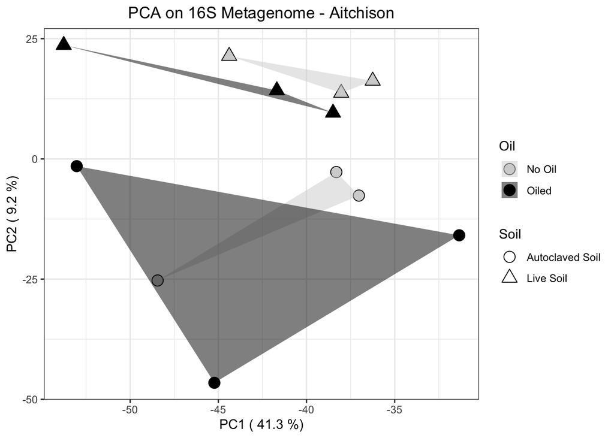

```r
#get summary data
pca.sum <- as.data.frame(summary(pca)$importance)
df.PCA <- cbind(PCA.scores,df.meta)

ggplot(data = df.PCA,
                aes(x = PC1,
                    y = PC2,
                    shape = soil,
                    fill = oil)) +
  my.scale_aes +
  labs(title = "PCA on 16S Metagenome - Aitchison",
       x = paste("PC1 (", round(pca.sum$PC1[2]*100, digits = 1), "%)"),
       y = paste("PC2 (", round(pca.sum$PC2[2]*100, digits = 1), "%)"))
```

```r
  #ggsave(".png", width = 10, height = 7, units = "in")
```

## Permanova - Aitchison

```r
set.seed(1)
mod1 <- adonis(comm.df ~ soil*oil, data = df.meta, method = "euclidean")
mod1
```

```
##
## Call:
## adonis(formula = comm.df ~ soil * oil, data = df.meta, method = "euclidean")
##
## Permutation: free
## Number of permutations: 999
##
## Terms added sequentially (first to last)
##
##           Df SumsOfSqs MeanSqs F.Model      R2 Pr(>F)
## soil       1    4182.6  4182.6 1.53936 0.13258  0.001 ***
## oil        1    2912.1  2912.1 1.07175 0.09231  0.209
## soil:oil   1    2715.2  2715.2 0.99929 0.08607  0.376
## Residuals  8   21736.9  2717.1         0.68904
## Total     11   31546.8                 1.00000
## ---
## Signif. codes:  0 '***' 0.001 '**' 0.01 '*' 0.05 '.' 0.1 ' ' 1
```

### Plot and PERMANOVA (adonis) of 16S - Bray-Curtis

```r
SF1.post.16S <- prune_samples(sample_data(SF1.16S)$time=="Post-Experiment", SF1.16S)

df <- otu_table(SF1.post.16S) %>%
  as.data.frame()

df.meta <- sample_data(SF1.post.16S) %>%
  data.frame()
```

#### Plot PCoA - BC

Used PCoA so it can be compared to the PCA (which is the equivalent when PCoA is based on Euclidean)

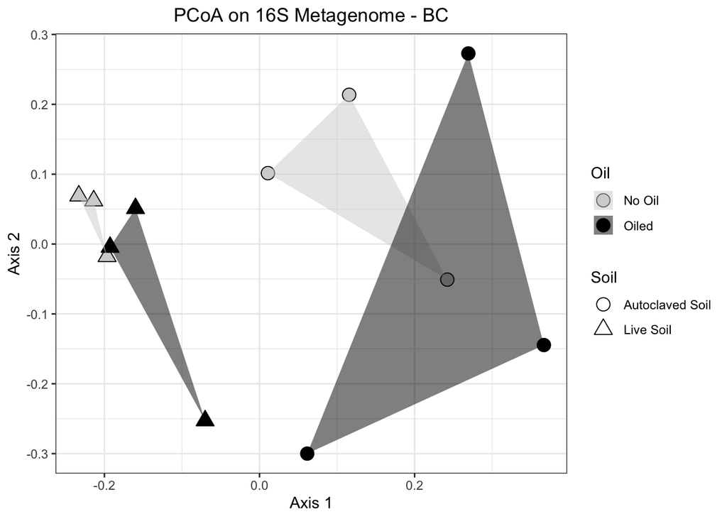

```r
set.seed(1)

SF1.ord <- ordinate(SF1.post.16S, method = "PCoA", distance = "bray")

B <- plot_ordination(SF1.post.16S, SF1.ord, type="samples", color="oil")

ggplot(data = B$data,
       aes(x = Axis.1,
           y = Axis.2,
           shape = soil,
                    fill = oil)) +
  my.scale_aes +
  labs(title = "PCoA on 16S Metagenome - BC",
       x = "Axis 1",
       y = "Axis 2")
```

```r
#ggsave(".png", width = 10, height = 7, units = "in")
```

## Plot NMDS - BC

```r
set.seed(1)

SF1.ord <- ordinate(SF1.post.16S, method = "NMDS", distance = "bray")
```

```
## Square root transformation
## Wisconsin double standardization
## *** Solution reached
```

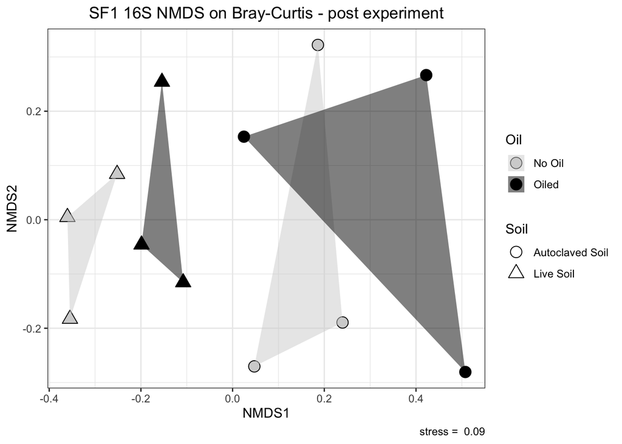

```r
B <- plot_ordination(SF1.post.16S, SF1.ord, type="samples", color="oil")

ggplot(data = B$data,
       aes(x = NMDS1,
           y = NMDS2,
          shape = soil,
          fill = oil)) +
  my.scale_aes +
  labs(title = "SF1 16S NMDS on Bray-Curtis - post experiment",
       caption = paste("stress = ", round(SF1.ord$stress, digits = 2), sep = " "))
```

```r
#ggsave(".png", width = 10, height = 7, units = "in")
```

## Permanova - BC

```r
set.seed(1)
mod1 <- adonis(df ~ soil*oil, data = df.meta, method = "bray")
mod1
```

```
##
## Call:
## adonis(formula = df ~ soil * oil, data = df.meta, method = "bray")
##
## Permutation: free
## Number of permutations: 999
##
## Terms added sequentially (first to last)
##
##           Df SumsOfSqs MeanSqs F.Model      R2 Pr(>F)
## soil       1   0.41002 0.41002 2.87198 0.21953  0.001 ***
## oil        1   0.17631 0.17631 1.23495 0.09440  0.214
## soil:oil   1   0.13923 0.13923 0.97523 0.07455  0.416
## Residuals  8   1.14214 0.14277         0.61152
## Total     11   1.86770                 1.00000
## ---
## Signif. codes:  0 '***' 0.001 '**' 0.01 '*' 0.05 '.' 0.1 ' ' 1
```

### Plot and PERMANOVA (adonis) of 16S - Jaccard index

```r
SF1.post.16S <- prune_samples(sample_data(SF1.16S)$time=="Post-Experiment", SF1.16S)

#make binary
df <- otu_table(SF1.post.16S) %>%
  as.data.frame()

df[df > 0] <- 1

otu_table(SF1.post.16S) <- otu_table(df, taxa_are_rows = FALSE)

df.meta <- sample_data(SF1.post.16S) %>%
  data.frame()
```

## Plot PCoA - Jaccard

Used PCoA so it can be compared to the PCA (which is the equivalent when PCoA is based on Euclidean)

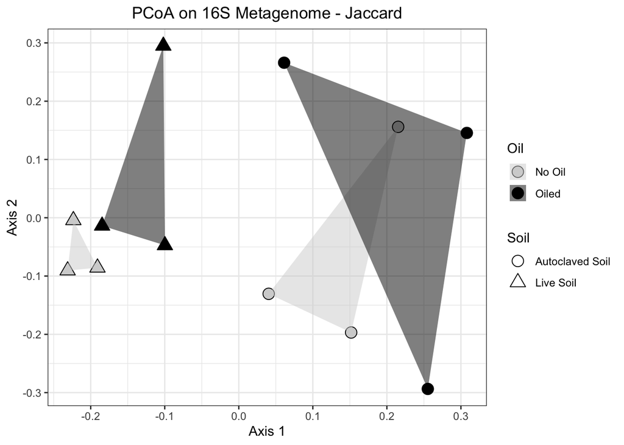

```r
set.seed(1)

SF1.ord <- ordinate(SF1.post.16S, method = "PCoA", distance = "jaccard", binary = TRUE)

B <- plot_ordination(SF1.post.16S, SF1.ord, type="samples", color="oil")

ggplot(data = B$data,
       aes(x = Axis.1,
           y = Axis.2,
           shape = soil,
           fill = oil)) +
  my.scale_aes +
  labs(title = "PCoA on 16S Metagenome - Jaccard",
       x = "Axis 1",
       y = "Axis 2")
```

```r
#ggsave(".png", width = 10, height = 7, units = "in")
```

## Plot NMDS - Jaccard

```r
set.seed(1)

SF1.ord <- ordinate(SF1.post.16S, method = "NMDS", distance = "jaccard", binary = TRUE)
```

```
## *** Solution reached
```

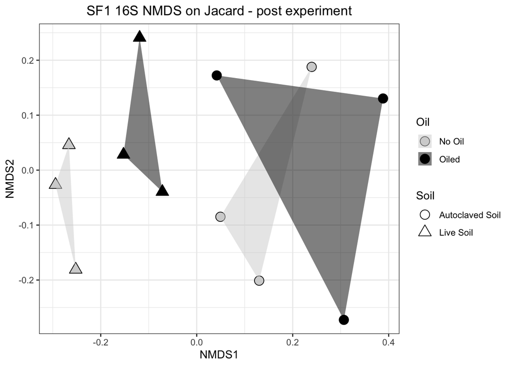

```r
B <- plot_ordination(SF1.post.16S, SF1.ord, type="samples", color="oil")

ggplot(data = B$data,
       aes(x = NMDS1,
           y = NMDS2,
           shape = soil,
           fill = oil)) +
  my.scale_aes +
  labs(title = "SF1 16S NMDS on Jacard - post experiment")
```

```r
#ggsave(".png", width = 10, height = 7, units = "in")
```

## Permanova - Jaccard

```r
set.seed(1)
mod1 <- adonis(df ~ soil*oil, data = df.meta, method = "jaccard", binary = TRUE)
mod1
```

```
##
## Call:
## adonis(formula = df ~ soil * oil, data = df.meta, method = "jaccard",      binary = TRUE)
##
## Permutation: free
## Number of permutations: 999
##
## Terms added sequentially (first to last)
##
##           Df SumsOfSqs MeanSqs F.Model      R2 Pr(>F)
## soil       1    0.4009 0.40090  1.4297 0.12446  0.001 ***
## oil        1    0.2937 0.29369  1.0474 0.09118  0.249
## soil:oil   1    0.2832 0.28321  1.0100 0.08793  0.339
## Residuals  8    2.2432 0.28040         0.69643
## Total     11    3.2210                 1.00000
## ---
## Signif. codes:  0 '***' 0.001 '**' 0.01 '*' 0.05 '.' 0.1 ' ' 1
```

## ITS

### Plot and PERMANOVA (adonis) of ITS - Aitchison

```r
SF1.post.ITS <- prune_samples(sample_data(SF1.ITS)$time=="Post-Experiment", SF1.ITS)

df <- otu_table(SF1.post.ITS) %>%
  as.data.frame()

df.meta <- sample_data(SF1.post.ITS) %>%
  data.frame()

clr.df <- clr(df)
pca = prcomp(clr.df, center = FALSE, scale. = FALSE)

PCA.loadings=pca$rotation
PCA.scores = pca$x

#For below analyses
comm.df <- clr.df %>%
  as.data.frame()
```

## Permanova - Aitchison

```r
set.seed(1)
mod1 <- adonis(comm.df ~ soil*oil, data = df.meta, method = "euclidean")
mod1
```

```
##
## Call:
## adonis(formula = comm.df ~ soil * oil, data = df.meta, method = "euclidean")
##
## Permutation: free
## Number of permutations: 999
##
## Terms added sequentially (first to last)
##
##           Df SumsOfSqs MeanSqs F.Model      R2 Pr(>F)
## soil       1     581.1  581.09 1.26762 0.11347  0.124
## oil        1     456.5  456.52 0.99586 0.08915  0.399
## soil:oil   1     416.1  416.05 0.90759 0.08125  0.598
## Residuals  8    3667.3  458.41         0.71614
## Total     11    5120.9                 1.00000
```

## Plot PCA - Aitchison

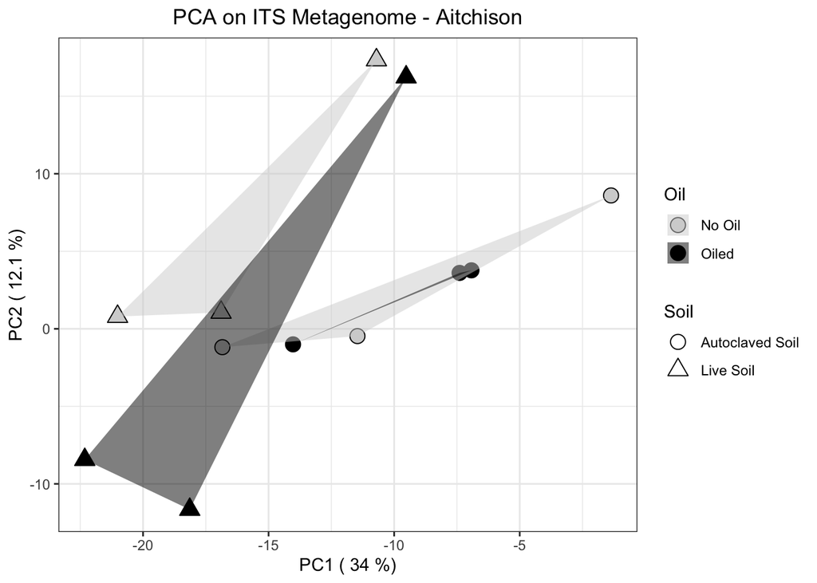

```r
#get summary data
pca.sum <- as.data.frame(summary(pca)$importance)
df.PCA <- cbind(PCA.scores,df.meta)

ggplot(data = df.PCA,
                aes(x = PC1,
                    y = PC2,
                    shape = soil,
                    fill = oil)) +
  my.scale_aes +
  labs(title = "PCA on ITS Metagenome - Aitchison",
       x = paste("PC1 (", round(pca.sum$PC1[2]*100, digits = 1), "%)"),
       y = paste("PC2 (", round(pca.sum$PC2[2]*100, digits = 1), "%)"))
```

```r
  #ggsave(".png", width = 10, height = 7, units = "in")
```

### PERMANOVA (adonis) of ITS - Bray-Curtis

```r
SF1.post.ITS <- prune_samples(sample_data(SF1.ITS)$time=="Post-Experiment", SF1.ITS)

df <- otu_table(SF1.post.ITS) %>%
  as.data.frame()

df.meta <- sample_data(SF1.post.ITS) %>%
  data.frame()
```

## Plot

Used PCoA so it can be compared to the PCA (which is the equivalent when PCoA is based on Euclidean)

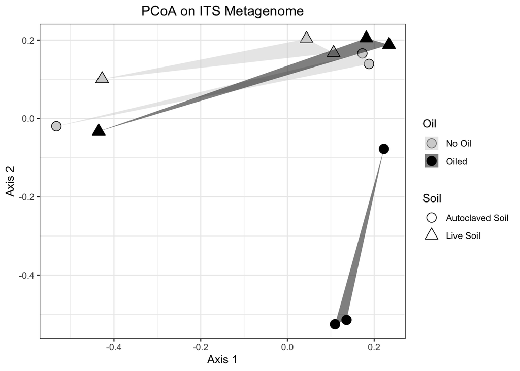

```r
set.seed(1)

SF1.ord <- ordinate(SF1.post.ITS, method = "PCoA", distance = "bray")

B <- plot_ordination(SF1.post.ITS, SF1.ord, type="samples", color="oil")

ggplot(data = B$data,
       aes(x = Axis.1,
           y = Axis.2,
           shape = soil,
           fill = oil)) +
  my.scale_aes +
  labs(title = "PCoA on ITS Metagenome",
       x = "Axis 1",
       y = "Axis 2")
```

```r
#ggsave(".png", width = 10, height = 7, units = "in")
```

## Plot

```r
set.seed(1)

SF1.ord <- ordinate(SF1.post.ITS, method = "NMDS", distance = "bray")
```

```
## Square root transformation
## Wisconsin double standardization
## *** No convergence -- monoMDS stopping criteria:
##     20: stress ratio > sratmax
```

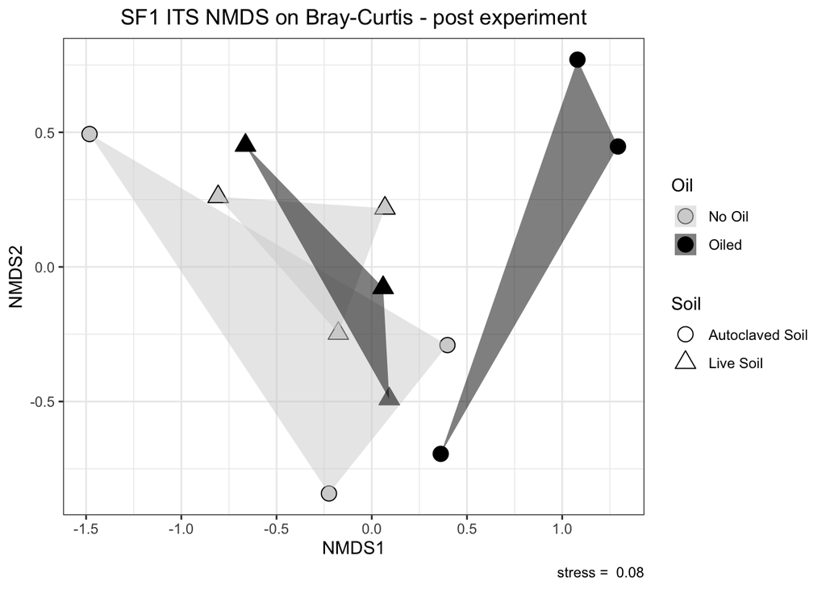

```r
B <- plot_ordination(SF1.post.ITS, SF1.ord, type="samples", color="oil")

ggplot(data = B$data,
       aes(x = NMDS1,
           y = NMDS2,
           shape = soil,
           fill = oil)) +
  my.scale_aes +
  labs(title = "SF1 ITS NMDS on Bray-Curtis - post experiment",
       caption = paste("stress = ", round(SF1.ord$stress, digits = 2), sep = " "))
```

```r
#ggsave(".png", width = 10, height = 7, units = "in")
```

## Permanova

```r
set.seed(1)
mod1 <- adonis(df ~ soil*oil, data = df.meta, method = "bray")
mod1
```

```
##
## Call:
## adonis(formula = df ~ soil * oil, data = df.meta, method = "bray")
##
## Permutation: free
## Number of permutations: 999
##
## Terms added sequentially (first to last)
##
##           Df SumsOfSqs MeanSqs F.Model      R2 Pr(>F)
## soil       1    0.4849 0.48492  1.6096 0.13166  0.065 .
## oil        1    0.4389 0.43886  1.4567 0.11915  0.114
## soil:oil   1    0.3492 0.34923  1.1592 0.09482  0.320
## Residuals  8    2.4102 0.30127         0.65437
## Total     11    3.6832                 1.00000
## ---
## Signif. codes:  0 '***' 0.001 '**' 0.01 '*' 0.05 '.' 0.1 ' ' 1
```

### PERMANOVA (adonis) of ITS - Jaccard index

```r
SF1.post.ITS <- prune_samples(sample_data(SF1.ITS)$time=="Post-Experiment", SF1.ITS)

#make binary
df <- otu_table(SF1.post.ITS) %>%
  as.data.frame()

df[df > 0] <- 1

otu_table(SF1.post.ITS) <- otu_table(df, taxa_are_rows = FALSE)

df.meta <- sample_data(SF1.post.ITS) %>%
  data.frame()
```

## Plot

Used PCoA so it can be compared to the PCA (which is the equivalent when PCoA is based on Euclidean)

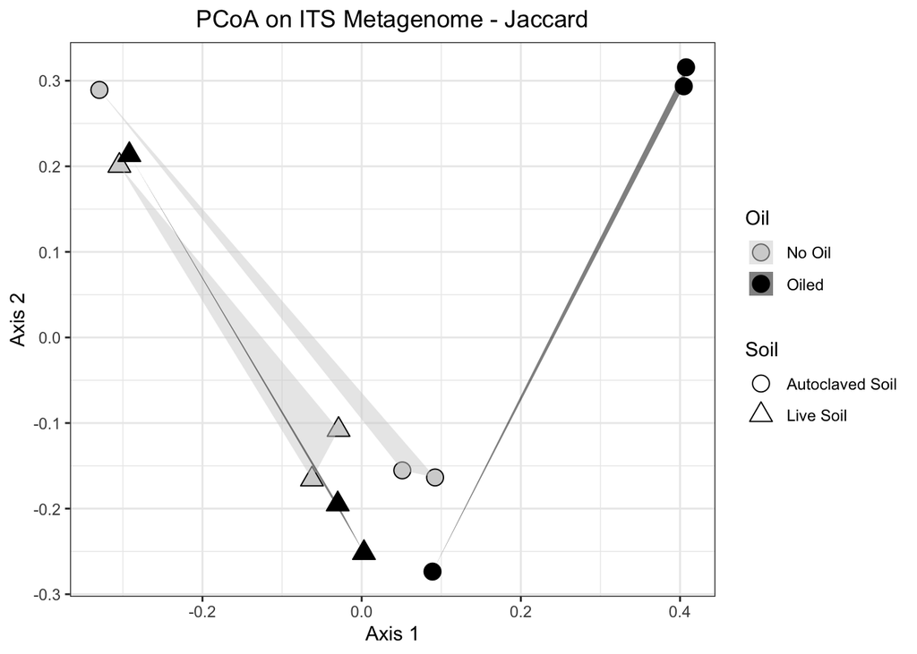

```r
set.seed(1)

SF1.ord <- ordinate(SF1.post.ITS, method = "PCoA", distance = "jaccard", binary = TRUE)

B <- plot_ordination(SF1.post.ITS, SF1.ord, type="samples", color="oil")

ggplot(data = B$data,
       aes(x = Axis.1,
           y = Axis.2,
           shape = soil,
                    fill = oil)) +
  my.scale_aes +
  labs(title = "PCoA on ITS Metagenome - Jaccard",
       x = "Axis 1",
       y = "Axis 2")
```

```r
#ggsave(".png", width = 10, height = 7, units = "in")
```

## Plot

```r
set.seed(1)

SF1.ord <- ordinate(SF1.post.ITS, method = "NMDS", distance = "jaccard", binary = TRUE)
```

```
## *** Solution reached
```

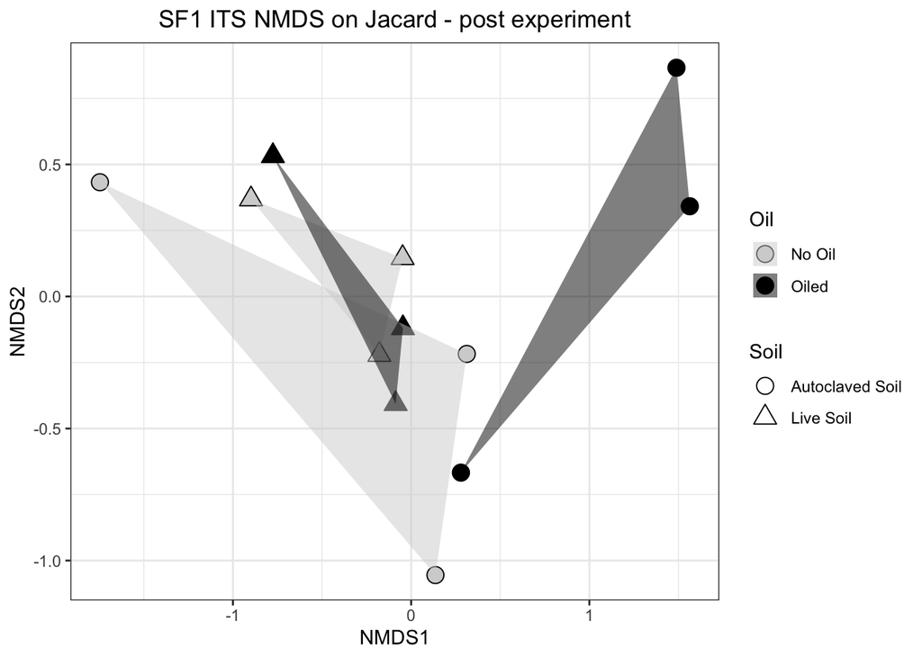

```r
B <- plot_ordination(SF1.post.ITS, SF1.ord, type="samples", color="oil")

ggplot(data = B$data,
       aes(x = NMDS1,
           y = NMDS2,
           shape = soil,
                    fill = oil)) +
  my.scale_aes +
  labs(title = "SF1 ITS NMDS on Jacard - post experiment")
```

```r
#ggsave(".png", width = 10, height = 7, units = "in")
```

## Permanova

```r
set.seed(1)
mod1 <- adonis(df ~ soil*oil, data = df.meta, method = "jaccard", binary = TRUE)
mod1
```

```
##
## Call:
## adonis(formula = df ~ soil * oil, data = df.meta, method = "jaccard",      binary = TRUE)
##
## Permutation: free
## Number of permutations: 999
##
## Terms added sequentially (first to last)
##
##           Df SumsOfSqs MeanSqs F.Model      R2 Pr(>F)
## soil       1    0.4711 0.47108 1.34229 0.11836  0.025 *
## oil        1    0.3484 0.34842 0.99278 0.08754  0.471
## soil:oil   1    0.3530 0.35305 1.00598 0.08870  0.460
## Residuals  8    2.8076 0.35095         0.70540
## Total     11    3.9801                 1.00000
## ---
## Signif. codes:  0 '***' 0.001 '**' 0.01 '*' 0.05 '.' 0.1 ' ' 1
```